# Bioestadística, Economía

Clase 11: TLC, Valor esperado, varianza y Percentiles

Departamento de Estadı́stica, Sede Bogotá

## Contenido

### Medidas de centro

- Teorema Central de Limite.
- Valor esperado discreto y continuo.
- Interpretación geométrica.
- Esperanza de una función.
- Propiedades del valor esperado.

### Dispersión y posición

- Varianza y desviación estándar.
- Asimetría y curtosis.
- Percentiles y cuartiles.
- IQR, Chebyshev y taller.

Teorema Central del Límite (TLC)

Resumiendo dice que, si tomamos muchas muestras suficientemente grandes de una población, entonces los promedios de esas muestras tienden a seguir una distribución normal, incluso si los datos originales no son normales.

## ¿Por qué es importante el TLC?

- En muchas aplicaciones reales, la población original no sigue una distribución normal.
- Por ejemplo, los rentabilidades económicos, pesos de frutos o ventas del sector comercio suelen presentar **asimetría**.
- Aun así, necesitamos métodos estadísticos confiables para hacer inferencia y tomar decisiones.
- El **(TCL)** explica por qué las medias muestrales tienden a comportarse normalmente.
- Esto permite construir intervalos de confianza y realizar pruebas de hipótesis.
- Es uno de los resultados más importantes de toda la estadística aplicada.

## Idea intuitiva del TLC

Población original

La variable original puede ser:

- asimétrica,
- irregular,
- o tener colas pesadas.
- No normal

Media muestral

Si tomamos muchas muestras de tamaño $n$ y calculamos:

$$\bar X$$

las medias muestrales tienden a distribuirse aproximadamente como una normal.

## Definición

Supuestos

Sea:

$$X_1,X_2,\ldots,X_n$$

una muestra aleatoria independiente con:

$$E(X)=\mu$$

$$\text{Var}(X)=\sigma^2$$

Resultado del TCL

Cuando el tamaño de muestra es grande,

$$\bar X
\approx
N\left(
\mu,
\frac{\sigma^2}{n}
\right)$$

Equivalentemente,

$$Z=
\frac{\bar X-\mu}
{\sigma/\sqrt n}
\approx N(0,1)$$

## Interpretación del Teorema Central del Límite

#### Centro de la distribución

- La media de las medias muestrales coincide con la media poblacional:

  $$E(\bar X)=\mu$$
- Las medias muestrales se concentran alrededor del verdadero valor poblacional.
- Por esta razón, $\bar X$ es un estimador natural del parámetro $\mu$.

#### Variabilidad de la media

- La desviación estándar de la media muestral es:

  $$\frac{\sigma}{\sqrt n}$$
- A medida que aumenta $n$, la dispersión disminuye.
- Las estimaciones se vuelven más precisas, estables y cercanas a $\mu$.

El TCL explica por qué la distribución normal aparece tan frecuentemente en estadística aplicada.

## Condiciones del Teorema Central del Límite

- Las observaciones deben ser independientes.
- La varianza poblacional debe ser finita.
- El tamaño de muestra debe ser suficientemente grande.
- Una regla práctica frecuente es:
  $$n \geq 30$$
- Distribuciones muy asimétricas pueden requerir tamaños mayores.
- Mientras mayor sea $n$, mejor será la aproximación a la distribución normal.

## Ejemplo 1

En una empresa comercial, la producción diaria de comercio por empresa tiene media $\mu = 2.4 \text{kg}$ y desviación estándar $\sigma = 0.8 \text{kg}$. Si se selecciona una muestra aleatoria de: $n = 64$ empresas. Entonces, usando el **Teorema Central del Límite**:

1. Determine cómo se distribuye la media muestral $\bar X$.
2. Calcule el error estándar de $\bar X$.

## Solución

1. Distribución muestral

Por el Teorema Central del Límite:

$\bar X\approx N\left(\mu,\frac{\sigma^2}{n}\right)$

Sustituyendo:

$$\mu = 2.4,
\qquad
\sigma = 0.8,
\qquad
n=64$$

obtenemos:

$\bar X\approx N\left(2.4,\frac{0.8^2}{64}\right)$

#### Error estándar

- La desviación estándar de $\bar X$ es: $\frac{\sigma}{\sqrt n}$
- Entonces:

  $$\frac{0.8}{\sqrt{64}}=0.1$$
- Finalmente:

  $$\bar X
  \approx
  N(2.4,0.1^2)$$

## Ejemplo 2

Enunciado

La rentabilidad por sucursal de servicios tiene $\mu = 6.5 \text{Ton}$ y $\sigma = 1.2 \text{Ton}$. Se selecciona una muestra aleatoria de $n=36$ sucursales. Calcular la probabilidad de que la rentabilidad promedio supere las 6.8 toneladas.

Solución

Por el TCL: $\bar X\approx N\left(6.5,\frac{1.2^2}{36}\right)$

El error estándar es: $\sigma_{\bar X} = \frac{1.2}{\sqrt{36}}=0.2$

Estandarizando:

$$Z= \frac{6.8-6.5}{0.2} = 1.5$$

Entonces:

$$P(\bar X>6.8)
=P(Z>1.5)\\
=1-P(Z \leq 1.5)
\approx 0.0668$$

Existe aproximadamente un 6.68% de probabilidad de que la media muestral supere las 6.8 millones por sucursal.

Valor esperado discreto y continuo

## ¿Por qué resumir una distribución?

- La FMP o FDP describe *toda* la distribución, pero trabajar con ella completa no siempre es práctico.
- Necesitamos **resúmenes numéricos** que capturen las características esenciales: ¿dónde está el centro?, ¿cuánta dispersión hay?
- El **valor esperado** responde: ¿cuál es el valor promedio a largo plazo?
- La **varianza** responde: ¿qué tan dispersos están los valores alrededor del promedio?
- Los **percentiles** responden: ¿qué valor supera a un porcentaje dado de la distribución?

## Valor esperado para variable discreta

Definición

Si $X$ es una variable aleatoria discreta con FMP $p(x)$, su **valor esperado** es:
$$E(X) = \sum_{x \in \text{soporte}} x \cdot p(x)$$
siempre que la suma sea absolutamente convergente.

- $E(X)$ es el **promedio ponderado** de los valores posibles, con pesos iguales a sus probabilidades.
- También llamado *media*, *expectativa* o *primer momento* de $X$. Se denota $\mu_X$ o simplemente $\mu$.

## Valor esperado para variable continua

Definición

Si $X$ es una variable aleatoria continua con FDP $f(x)$, su **valor esperado** es:
$$E(X) = \int_{-\infty}^{\infty} x\, f(x)\, dx$$
siempre que la integral sea absolutamente convergente.

- La integral reemplaza a la suma: $x$ se pondera por la densidad $f(x)$ en cada punto.
- El valor esperado es el **centro de masa** de la distribución.

## Interpretación geométrica

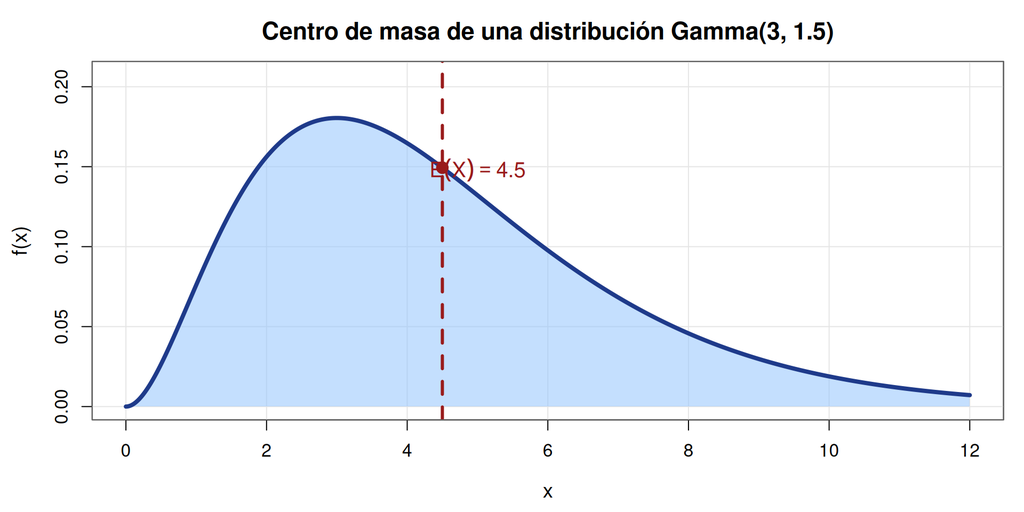

## Ejemplo 3

Lanzamiento de dado

Para un dado justo: $X \in \{1,2,3,4,5,6\}$, $p(x) = 1/6$.
$$E(X) = \frac{1+2+3+4+5+6}{6} = \frac{21}{6} = 3.5$$
El 3.5 nunca se observa, pero es el promedio a largo plazo de muchos lanzamientos.

En R

```r
# Verificación por simulación
set.seed(123)
mean(sample(1:6, 100000, replace=TRUE))
```

```
[1] 3.49489
```

## E(X) para distribuciones conocidas

| Distribución | Parámetros | $E(X)$ |
| --- | --- | --- |
| Bernoulli($p$) | $p$ | $p$ |
| Binomial($n,p$) | $n$, $p$ | $np$ |
| Poisson($\lambda$) | $\lambda$ | $\lambda$ |
| Uniforme($a,b$) | $a$, $b$ | $\frac{a+b}{2}$ |
| Normal($\mu,\sigma^2$) | $\mu$, $\sigma^2$ | $\mu$ |
| Exponencial($\lambda$) | $\lambda$ | $\frac{1}{\lambda}$ |
| Chi-cuadrado($\nu$) | $\nu$ | $\nu$ |
| t de Student($\nu$) | $\nu$ | $0 \; (\nu > 1)$ |

## Derivación: E(X) de la Binomial

Demostración: E(X) = np, para Bin(n,p)

$$E(X)=\sum_{k=0}^{n}
k\binom{n}{k}p^k(1-p)^{n-k}$$

Usando:

$$k\binom{n}{k}
=
n\binom{n-1}{k-1}$$

obtenemos:

$$E(X)=
\sum_{k=1}^{n}
n\binom{n-1}{k-1}
p^k(1-p)^{n-k}$$

Factorizando $np$:

$$E(X)=
np
\sum_{k=1}^{n}
\binom{n-1}{k-1}
p^{k-1}(1-p)^{n-k}$$

Con $j=k-1$:

$$E(X)=
np
\sum_{j=0}^{n-1}
\binom{n-1}{j}
p^j(1-p)^{(n-1)-j}$$

$$=
np(p+1-p)^{n-1}
=
\boxed{np}$$

## Cálculo de E(X) de la distrbución Exponencial

Demostración: E(X) = 1/λ, para Exp(λ)

Partimos de:

$$E(X)=\int_0^\infty
x\lambda e^{-\lambda x}\,dx$$

Aplicamos integración por partes:

$$u=x
\qquad
dv=\lambda e^{-\lambda x}dx$$

Entonces,

$$du=dx
\qquad
v=-e^{-\lambda x}$$

Sustituyendo:

$$E(X)=
\left[
-xe^{-\lambda x}
\right]_0^\infty
+
\int_0^\infty
e^{-\lambda x}dx$$

El primer término vale $0$, por lo que:

$$E(X)=
\int_0^\infty
e^{-\lambda x}dx$$

$$=
\left[
-\frac{1}{\lambda}
e^{-\lambda x}
\right]_0^\infty
=
\frac{1}{\lambda}$$

$$\boxed{
E(X)=\frac{1}{\lambda}
}$$

## Valor esperado de una función

Definición

Si $Y = g(X)$, no es necesario encontrar la distribución de $Y$:
$$E[g(X)] = \begin{cases} \displaystyle\sum_x g(x)\,p(x) & \text{(discreta)} \\[6pt] \displaystyle\int_{-\infty}^\infty g(x)\,f(x)\,dx & \text{(continua)} \end{cases}$$

- Por ejemplo: $E(X^2)$ se calcula directamente integrando $x^2 f(x)$, sin derivar primero la distribución de $X^2$.

## Propiedades del valor esperado

Para constantes $a$, $b$ y v.a. $X$, $Y$:

1. $E(a) = a$
2. $E(aX) = a\,E(X)$
3. $E(X + b) = E(X) + b$
4. $E(aX + b) = a\,E(X) + b$ **(linealidad)**
5. $E(X + Y) = E(X) + E(Y)$ **(siempre, sin importar independencia)**

La varianza

## Cálculo de la Varianza por medio del valor esperado

Definición

La **varianza** de $X$ mide la dispersión alrededor de la media:
$$\text{Var}(X) = E\!\left[(X - \mu)^2\right] = E(X^2) - [E(X)]^2$$
donde $\mu = E(X)$. La raíz cuadrada $\sigma = \sqrt{\text{Var}(X)}$ se llama **desviación estándar**.

- La fórmula $\text{Var}(X) = E(X^2) - \mu^2$ es computacionalmente conveniente.
- $\text{Var}(X) \geq 0$ siempre; es cero solo si $X$ es constante con probabilidad 1.

## Varianza para variables discretas y continuas

Variable discreta

Definición:

$$\text{Var}(X)
=
\sum_x (x-\mu)^2 p(x)$$

Forma equivalente:

$$\text{Var}(X)
=
\sum_x x^2 p(x)-\mu^2$$

donde $\mu = E(X)$

Variable continua

Definición:

$$\text{Var}(X)
=
\int_{-\infty}^{\infty}
(x-\mu)^2 f(x)\,dx$$

Forma equivalente:

$$\text{Var}(X)
=
\int_{-\infty}^{\infty}
x^2 f(x)\,dx-\mu^2$$

donde $\mu = E(X)$

## Varianza para distribuciones conocidas

| Distribución | $E(X)$ | $\text{Var}(X)$ |
| --- | --- | --- |
| Bernoulli($p$) | $p$ | $p(1-p)$ |
| Binomial($n,p$) | $np$ | $np(1-p)$ |
| Poisson($\lambda$) | $\lambda$ | $\lambda$ |
| Uniforme($a,b$) | $\frac{a+b}{2}$ | $\frac{(b-a)^2}{12}$ |
| Normal($\mu,\sigma^2$) | $\mu$ | $\sigma^2$ |
| Exponencial($\lambda$) | $\frac{1}{\lambda}$ | $\frac{1}{\lambda^2}$ |
| Gamma($\alpha,\beta$) | $\alpha\beta$ | $\alpha\beta^2$ |
| Chi-cuadrado($\nu$) | $\nu$ | $2\nu$ |
| t de Student($\nu$) | $0$, si $\nu>1$ | $\frac{\nu}{\nu-2}$, si $\nu>2$ |

## Propiedades de la varianza

Para constantes $a$, $b$ y v.a. $X$, $Y$ **independientes**:

1. $\text{Var}(a) = 0$
2. $\text{Var}(aX) = a^2\, \text{Var}(X)$
3. $\text{Var}(X + b) = \text{Var}(X)$
4. $\text{Var}(aX + b) = a^2\, \text{Var}(X)$
5. $\text{Var}(X + Y) = \text{Var}(X) + \text{Var}(Y)$

## Ejemplo 4

Distribución Poisson

El número semanal de casos de dengue en un municipio sigue $X \sim \text{Poi}(5)$.  
Calcule $E(X)$, $\text{Var}(X)$ y $\sigma$.

Solución

$$E(X) = \lambda = 5 \quad \text{casos/semana}$$
$$\text{Var}(X) = \lambda = 5$$
$$\sigma = \sqrt{5} \approx 2.24 \quad \text{casos/semana}$$

## Solución

```r
# X ~ Poi(5)
lambda <- 5
k <- 0:30
pk <- dpois(k, lambda)

# E(X) manual
EX <- sum(k * pk)
# E(X^2)
EX2 <- sum(k^2 * pk)
# Var(X) = E(X^2) - [E(X)]^2
VarX <- EX2 - EX^2

cat("E(X)   =", round(EX, 4), "\n")
```

```
E(X)   = 5
```

```r
cat("Var(X) =", round(VarX, 4), "\n")
```

```
Var(X) = 5
```

```r
cat("sd(X)  =", round(sqrt(VarX), 4), "\n")
```

```
sd(X)  = 2.2361
```

## Demostración Varianza de la Binomial

Var(X) = np(1-p) para Bin(n,p)

Sea $X = X_1 + \cdots + X_n$ con $X_i \sim \text{Ber}(p)$ independientes:
$$\text{Var}(X) = \sum_{i=1}^n \text{Var}(X_i) = n\,\text{Var}(X_1)$$
$$\text{Var}(X_1) = E(X_1^2) - [E(X_1)]^2 = p - p^2 = p(1-p)$$
$$\therefore \text{Var}(X) = np(1-p) \quad \square$$

Los momentos

Resumiendo, los momentos son números que describen la forma de una distribución. El primer momento describe el centro, el segundo momento describe la dispersión…

## Momentos de una distribución

Definición: Momentos

**Momento respecto al origen**
$$\mu_k' = E(X^k)$$

**Momento central**
$$\mu_k = E\!\left[(X-\mu)^k\right]$$

Media ($k=1$)

$$\mu = E(X)$$

Centro de gravedad de la distribución.

Varianza ($k=2$)

$$\sigma^2 = E\!\left[(X-\mu)^2\right]$$

Dispersión alrededor de la media.

Asimetría ($k=3$)

$$\gamma_1 = \frac{E[(X-\mu)^3]}{\sigma^3}$$

Inclinación izquierda o derecha.

Curtosis ($k=4$)

$$\gamma_2 = \frac{E[(X-\mu)^4]}{\sigma^4}$$

Peso de las colas respecto a la Normal.

## Asimetría y curtosis

Asimetría

Mide qué tan **simétrica** es una distribución respecto a su media.

$$\text{Asimetría}
=
\frac{E[(X-\mu)^3]}{\sigma^3}$$

- $\text{Asimetría}=0$

  Distribución simétrica.
- $\text{Asimetría}>0$

  Cola más larga hacia la derecha.
- $\text{Asimetría}<0$

  Cola más larga hacia la izquierda.

Curtosis

Mide qué tan **concentrados** están los datos y el peso de las colas.

$$\text{Curtosis}
=
\frac{E[(X-\mu)^4]}{\sigma^4}$$

- Curtosis alta:

  colas pesadas y más valores extremos.
- Curtosis baja:

  colas ligeras y menos extremos.
- Distribución normal:

  $$\text{Curtosis}=3$$

La asimetría describe la **dirección** de la distribución, mientras que la curtosis describe qué tan **pesadas** son sus colas.

## Gráfica Asimetría y curtosis

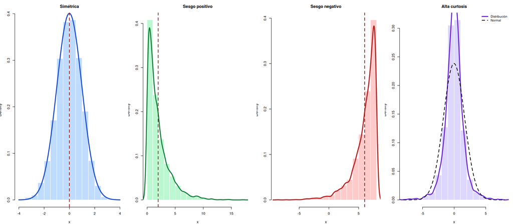

## Momentos generadores de probabilidad

Función generatriz de momentos (FGM)

La **FGM** de $X$ es $M_X(t) = E(e^{tX})$, definida en un entorno de $t=0$. Sus derivadas en $t=0$ dan los momentos:
$$M_X^{(k)}(0) = E(X^k)$$

- La Función Generatriz de Momentos (FGM) es una función matemática que resume toda la información importante de una distribución de probabilidad.
- La FGM identifica unívocamente la distribución: dos distribuciones con la misma FGM son iguales.
- Ejemplo: $M_{N(\mu,\sigma^2)}(t) = \exp(\mu t + \frac{1}{2}\sigma^2 t^2)$.

Desigualdad de Chebyshev

La desigualdad de Chebyshev dice que, en cualquier conjunto de datos, la mayoría de los valores estarán relativamente cerca del promedio.

## Desigualdad de Chebyshev

Definición

Para cualquier variable aleatoria $X$ con media $\mu$ y varianza finita $\sigma^2$:
$$P(|X - \mu| \geq k\sigma) \leq \frac{1}{k^2}, \quad k > 1$$
Equivalentemente: $P(|X - \mu| < k\sigma) \geq 1 - \frac{1}{k^2}$.

- Para $k=2$: al menos el 75% de los valores caen dentro de 2 desviaciones estándar de la media, sin importar la distribución.
- Aunque haya variabilidad en los empresas, animales o mercados, Chebyshev nos asegura que no muchos datos estarán demasiado lejos del promedio.

## Aplicaciones: Desigualdad de Chebyshev

La desigualdad de Chebyshev garantiza que **al menos** $1 - 1/k^2$ de los datos caen dentro de $k$ desviaciones estándar de la media, *sin importar la distribución*.

☕

Control de calidad en comercio

El valor de transacciones comerciales tiene $\mu = 70$ kg y $\sigma = 2$ kg. Con $k=2$, Chebyshev garantiza que **al menos el 75%** de los millones pesan entre 66 y 74 kg, sin asumir normalidad.

$P(66 \leq X \leq 74) \geq 75\%$

🌾

Rentabilidad de empresas

La rentabilidad de productos tiene $\mu = 4.2$ millones/sucursal y $\sigma = 0.6$ millones/sucursal. Con $k=3$, al menos el **89%** de los lotes producen entre 2.4 y 6.0 millones/sucursal, independiente de la forma de la distribución.

$P(2.4 \leq X \leq 6.0) \geq 88.9\%$

🐄

Producción de leche bovina

La producción diaria de un hato tiene $\mu = 18$ L y $\sigma = 3$ L. Con $k=2$, al menos el **75%** de las vacas producen entre 12 y 24 L, sin importar si la distribución es sesgada.

$P(12 \leq X \leq 24) \geq 75\%$

Útil cuando **no se conoce la distribución** exacta, da una cota inferior siempre válida.

## Comparación Chebyshev vs Normal

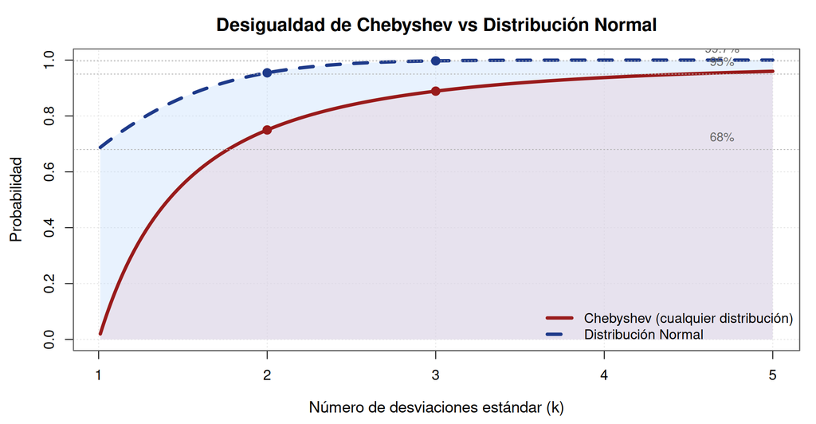

## Percentiles

Percentil $p$ de una variable aleatoria

El **percentil $p$**, denotado $\eta(p)$ o $x_p$, es el valor que acumula exactamente una probabilidad $p$:
$$F(\eta(p)) = P(X \leq \eta(p)) = p, \qquad 0 < p < 1$$
Equivalentemente, $\eta(p) = F^{-1}(p)$, la **función inversa de la FDA**.

Interpretación

El percentil $p$ divide la distribución: una proporción $p$ de los valores cae **por debajo** de $\eta(p)$ y una proporción $1-p$ cae por encima.

Ejemplo: $x_{0.75}$

El percentil 75 es el valor bajo el cual se encuentra el $75\%$ de la distribución. Es el tercer cuartil $Q_3$.
$$P(X \leq x_{0.75}) = 0.75$$

En R el prefijo `q` calcula percentiles: `qnorm(p)`, `qexp(p)`, `qgamma(p)`. El `q` viene de *quantile* = $F^{-1}(p)$.

## Percentiles variable continua

Definición

Para una v.a. continua con FDA $F$, el percentil $p$ es el valor $\eta(p)$ que satisface:
$$\int_{-\infty}^{\eta(p)} f(x)\,dx = p$$
En R: `qnorm(p, mu, sigma)`, `qexp(p, lambda)`, `qgamma(p, alpha, beta)`, etc.

- El prefijo `q` en R viene de *quantile* y calcula exactamente $F^{-1}(p)$.

## Cuartiles

Definición

- Los **cuartiles** dividen la distribución en cuatro partes iguales:
- $Q_1 = \eta(0.25)$: primer cuartil (percentil 25)
- $Q_2 = \eta(0.50)$: mediana (percentil 50)
- $Q_3 = \eta(0.75)$: tercer cuartil (percentil 75)
- El **rango intercuartílico** es $IQR = Q_3 - Q_1$.

## Cuartiles de la distribución Normal

```r
# Cuartiles de N(mu=50, sigma=10)
mu <- 50; sigma <- 10
Q1 <- qnorm(0.25, mu, sigma)
Q2 <- qnorm(0.50, mu, sigma)  # mediana
Q3 <- qnorm(0.75, mu, sigma)
IQR_val <- Q3 - Q1

cat("Q1 =", round(Q1, 2), "\n")
```

```
Q1 = 43.26
```

```r
cat("Q2 =", round(Q2, 2), "(mediana)\n")
```

```
Q2 = 50 (mediana)
```

```r
cat("Q3 =", round(Q3, 2), "\n")
```

```
Q3 = 56.74
```

```r
cat("IQR=", round(IQR_val, 2), "\n")
```

```
IQR= 13.49
```

## Mediana vs Media

Mediana

La **mediana** de una variable aleatoria $X$ es:

$$m=\eta(0.5)$$

y satisface:

$$P(X \leq m)=0.5$$

Es el valor que divide la distribución en dos partes iguales:

- $50\%$ de los datos queda por debajo de $m$
- $50\%$ queda por encima de $m$

La mediana es **robusta** frente a valores extremos.

Relación entre media y mediana

- **Distribución simétrica**

  $$\text{Media} \approx \text{Mediana}$$
- **Sesgo positivo**

  $$\text{Media} > \text{Mediana}$$

  La cola derecha arrastra la media.
- **Sesgo negativo**

  $$\text{Media} < \text{Mediana}$$

  La cola izquierda arrastra la media.

La mediana suele preferirse cuando existen **valores atípicos** o **asimetría fuerte**.

## Mediana de la Exponencial

Cálculo de la Mediana de Exp(λ)

La mediana $m$ de $X \sim \text{Exp}(\lambda)$:
$$F(m) = 1 - e^{-\lambda m} = 0.5 \implies e^{-\lambda m} = 0.5 \implies m = \frac{\ln 2}{\lambda}$$
Para $\lambda = 0.2$: $m = \ln(2)/0.2 \approx 3.47$ horas, mientras que $E(X) = 1/0.2 = 5$ horas.

En R

```r
lambda <- 0.2
c(mediana = qexp(0.5, lambda), media = 1/lambda)
```

```
 mediana    media
3.465736 5.000000
```

## Ejemplo 5

Distribución Normal

La talla de niños de 5 años en Colombia sigue $X \sim N(109, 5^2)$ cm. Calcule:

1. El percentil 10 (talla baja).
2. El percentil 90 (talla alta).
3. La proporción de niños entre $Q_1$ y $Q_3$.

```r
mu <- 109; sigma <- 5
# P10 y P90
qnorm(0.10, mu, sigma)
```

```
[1] 102.5922
```

```r
qnorm(0.90, mu, sigma)
```

```
[1] 115.4078
```

```r
# Proporción entre Q1 y Q3 (siempre 50% en cualquier distribución)
diff(pnorm(qnorm(c(0.25, 0.75), mu, sigma), mu, sigma))
```

```
[1] 0.5
```

## Visualización de percentiles (Ejemplo 5)

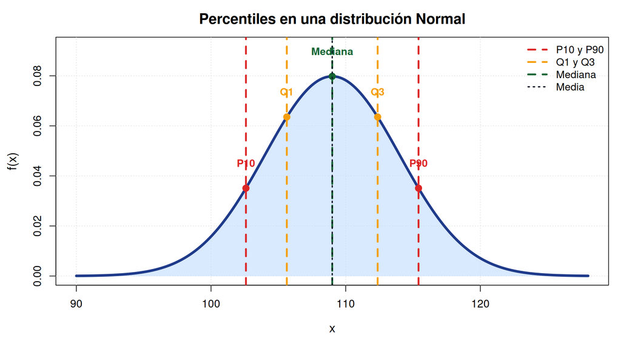

## Uso práctico del rango intercuartílico

IQR como medida de dispersión robusta

El $IQR = Q_3 - Q_1$ contiene el **50% central** de la distribución. Es insensible a valores extremos, a diferencia de la varianza.
Regla para outliers (Tukey): un valor $x$ es atípico si:
$$x < Q_1 - 1.5 \cdot IQR \quad \text{o} \quad x > Q_3 + 1.5 \cdot IQR$$

## Relación entre σ y IQR en la distribución normal

IQR de la Normal

Para $X \sim N(\mu, \sigma^2)$:
$$IQR = Q_3 - Q_1 = \mu + 0.6745\sigma - (\mu - 0.6745\sigma) = 2 \times 0.6745\sigma \approx 1.35\sigma$$

IQR de la Normal

```r
# Verificación
sigma <- 1
IQR_norm <- diff(qnorm(c(0.25, 0.75)))
cat("IQR N(0,1) =", round(IQR_norm, 4), "\n")
```

```
IQR N(0,1) = 1.349
```

```r
cat("1.35*sigma =", round(1.35*sigma, 4), "\n")
```

```
1.35*sigma = 1.35
```

## Cuartiles de distribuciones asimétricas

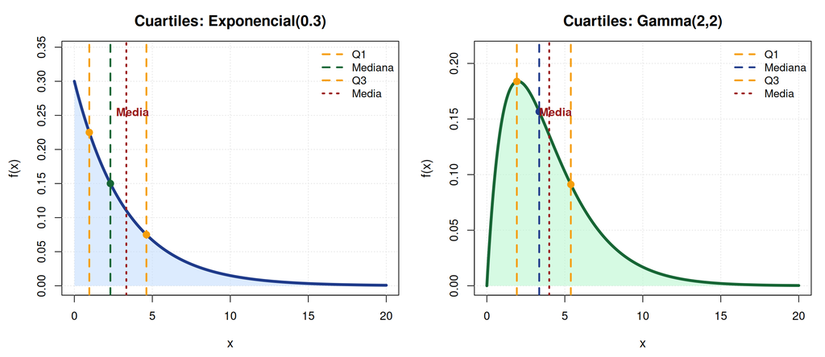

## Ejemplo 6

Enunciado

Sea $X$ el número de procedimientos fallidos en una jornada quirúrgica, con:

| $x$ | 0 | 1 | 2 | 3 |
| --- | --- | --- | --- | --- |
| $p(x)$ | 0.50 | 0.30 | 0.15 | 0.05 |

Calcule $E(X)$, $E(X^2)$, $\text{Var}(X)$ y $\sigma$.

## Solución

```r
x  <- c(0, 1, 2, 3)
px <- c(0.50, 0.30, 0.15, 0.05)
EX  <- sum(x * px)
EX2 <- sum(x^2 * px)
VX  <- EX2 - EX^2
cat("E(X)   =", EX, "\n")
```

```
E(X)   = 0.75
```

```r
cat("Var(X) =", round(VX, 4), "\n")
```

```
Var(X) = 0.7875
```

```r
cat("sd(X)  =", round(sqrt(VX), 4), "\n")
```

```
sd(X)  = 0.8874
```

## Ejemplo 7

Enunciado

El tiempo de recuperación (días) de pacientes con hepatitis A sigue $X \sim \text{Gamma}(\alpha=4, \beta=7)$. Calcule:

1. $E(X)$ y $\text{Var}(X)$.
2. El percentil 90 (tiempo que el 90% de pacientes ya se recuperó).
3. La probabilidad de recuperarse en menos de 20 días.

## Solución

```r
alpha <- 4; beta <- 7
# E(X) y Var(X)
cat("E(X)   =", alpha*beta, "días\n")
```

```
E(X)   = 28 días
```

```r
cat("Var(X) =", alpha*beta^2, "días²\n")
```

```
Var(X) = 196 días²
```

```r
cat("sd(X)  =", round(sqrt(alpha*beta^2),2), "días\n")
```

```
sd(X)  = 14 días
```

```r
# Percentil 90
cat("P90    =", round(qgamma(0.90, alpha, scale=beta), 2), "días\n")
```

```
P90    = 46.77 días
```

```r
# P(X < 20)
cat("P(X<20)=", round(pgamma(20, alpha, scale=beta), 4), "\n")
```

```
P(X<20)= 0.3208
```

## Ejemplo 8

Valor Esperado como criterio

El valor esperado puede usarse como **criterio de decisión** en situaciones con incertidumbre: elegir la acción que maximiza $E[\text{ganancia}]$ o minimiza $E[\text{pérdida}]$.

Enunciado

Si vacunar un rebaño cuesta $200 por animal y la infección cuesta $800 con probabilidad 0.4, ¿conviene vacunar?

- $E[\text{costo sin vacuna}] = 0.4 \times 800 = \$320$ por animal.
- $E[\text{costo con vacuna}] = \$200$ fijo.
- Vacunar es la decisión con menor costo esperado.

## Taller en clase

Ejercicios para resolver en clase

Valor esperado, varianza y percentiles

## 1. E(X) y Var(X) desde la definición

Problema

El número de crías nacidas vivas por parto en una especie de mamífero silvestre tiene la siguiente distribución:

| $x$ | 1 | 2 | 3 | 4 |
| --- | --- | --- | --- | --- |
| $p(x)$ | 0.20 | 0.45 | 0.25 | 0.10 |

1. Calcule $E(X)$ a mano y verifique en R.
2. Calcule $\text{Var}(X)$ usando $E(X^2) - [E(X)]^2$.
3. Interprete $\sigma$ en el contexto del problema.
4. ¿Cuántas crías se esperan en 50 partos? ¿Cuál es la desviación estándar total?

## 2. Propiedades de E(X) y Var(X)

Problema

Sea $X$ el peso corporal (kg) de una nutria gigante con $E(X) = 22$ kg y $\text{Var}(X) = 9$ kg².

1. Calcule $E(2X - 5)$ y $\text{Var}(2X - 5)$.
2. Si $Y$ es el peso en libras: $Y = 2.205 X$. Calcule $E(Y)$ y $\sigma_Y$.
3. Si $W = X_1 + X_2$ (suma de dos nutrias independientes), calcule $E(W)$ y $\text{Var}(W)$.
4. ¿Cuánto debe valer $a$ para que $E(aX) = 1$? ¿Y $\text{Var}(aX) = 1$?

## 3. Percentiles y cuartiles

Problema

La presión arterial sistólica (mmHg) en adultos mayores de 60 años de una población rural colombiana sigue $X \sim N(138,\; 18^2)$.

1. Calcule $Q_1$, $Q_2$ (mediana) y $Q_3$. ¿Son iguales a $\mu$?
2. Calcule el $IQR$ y compárelo con $1.35\sigma$.
3. ¿Qué presión define el umbral del 5% superior (hipertensión severa)?
4. Un paciente tiene 160 mmHg. ¿En qué percentil se ubica?

## 4. Chebyshev en la práctica

Problema

El número de huevos de *Ascaris lumbricoides* por gramo de heces tiene media $\mu = 1200$ y desviación estándar $\sigma = 400$ (distribución desconocida).

1. Use Chebyshev para garantizar que al menos el 75% de los valores caen en el intervalo $(\mu - k\sigma,\; \mu + k\sigma)$. ¿Qué $k$ se necesita?
2. Con ese $k$, calcule el intervalo en unidades de huevos/g.
3. Si asumiera normalidad, ¿cuál sería la probabilidad real en ese mismo intervalo?
4. ¿Por qué Chebyshev es más conservador?

## Resumen: E(X), Var(X) y percentiles

Centro y dispersión

- $E(X) = \mu$: valor promedio a largo plazo
- $\text{Var}(X) = E[(X-\mu)^2]$: dispersión cuadrática
- $\sigma = \sqrt{\text{Var}(X)}$: en las mismas unidades de $X$
- $CV = \sigma/|\mu|$: dispersión relativa

Posición y forma

- $\eta(p) = F^{-1}(p)$: percentil $p$
- $Q_1, Q_2, Q_3$: cuartiles
- $IQR = Q_3 - Q_1$: dispersión robusta
- Asimetría y curtosis: forma de la distribución

## Propiedades clave en resumen

Para recordar

- $E(aX+b) = aE(X)+b$, linealidad de la esperanza
- $\text{Var}(aX+b) = a^2\text{Var}(X)$, traslación no cambia varianza
- $\text{Var}(X+Y) = \text{Var}(X)+\text{Var}(Y)$ si $X$, $Y$ variables independientes
- $P(|X-\mu|\geq k\sigma) \leq 1/k^2$, Chebyshev
- Para la Normal: IQR $\approx 1.35\sigma$